# $Introduction\;to\;Machine-learning\;in\;Motion\;analysis$

# $Contents\; of\; tutorial$

$Feature\; extraction \; from \; 2nd\; order\; matrices$

- Non-negative matrix factorisation, Principal component analysis and Independent component analysis

$Feature\; extraction\; from\; 3rd\; order\; matrices$

- Tucker, Non-negative Tucker and Parafac tensor decompositions.

$Classification$

- Support vector machines, K-Nearest Neighbors and Linear Discriminant analysis

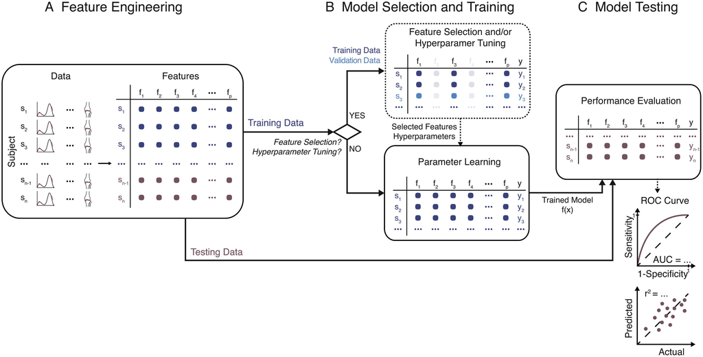

### $Example\; data\; for\; this\; tutorial$

$ This\; dataset\; contains\; 320\; slow\; reaching\; trials\; and\; 320\; fast\; reaching\; trials\; in$ $a\; number\; of\; forward\; and\; backward\; directions$

$The\;initials\;stand\;for\;different\;muscles,\;toggle\; between\; muscles\;below\;to \;inspect\;the\;EMG \;waveform....$

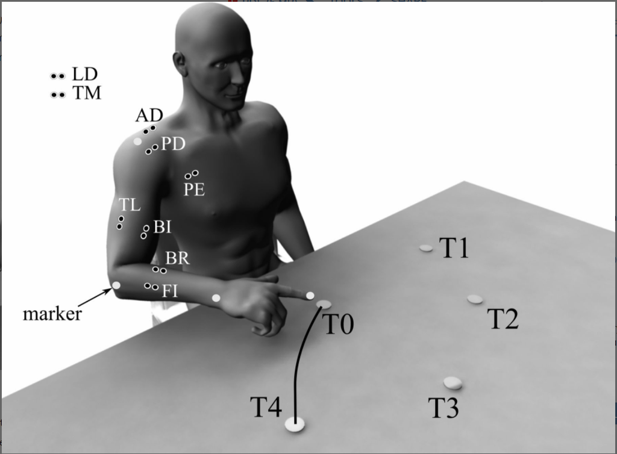

```python
data=pd.read_excel('EMG_daven1.xlsx')
task_data=pd.read_excel(r'C:\Users\david\Documents\MATLAB\Tutorial material\trg.xlsx')
widg1=interact(plot_func,Muscle = widgets.FloatSlider(value=4.0,
                                               min=1.0,
                                               max=9.0,
                                               step=1), continuous_update=False)
```

$Now, \; select\; the\; type\; and\; number\; of\; trials\; you\;$ $want\; for\; training\; the\; machine-learning\; algorthims\; below$

$Choices\; include:$  
$-Normalization\; by\; maximum\; or\; average\; values$  
$-Fast,\; slow\; or\; both\; speed\; trial\; types$  
$-The\; number\; of\; trials\; you\; would\; like$

```python
widg2=interactive(func_data, Normalisation= widgets.IntSlider(value=1,
                                               min=1,
                                               max=2,
                                               step=1),
                   Speed= widgets.IntSlider(value=1,
                                                   min=1,
                                               max=3,
                                               step=1),
               Trials = widgets.IntSlider(value=320,
                                               min=1,
                                               max=640,
                                               step=1), continuous_update=False)
display(widg2)
```

## $Feature\; extraction\; from\; 2nd\; order\; matrices$

$This\; example\; data\; has\; already\; been \;filtered\; and\; pre-processed,\;$  
$so\; we\; are \;ready\; to \;extract \;the\; main\; features....$

$In\; this\; tutorial,\; we\; have\; provided\; three\; algorithms\; to \;explore,\;$  
$including\; Non-negative\; matrix\; factorisation,\;Principle\; component \;analysis \; and \;Independent \;component \;analysis$

$Each\; algorithm\; has\; its\; advantages\; and\; limitations\;...compare\; their\; output\;$  
$using\; the\; data\; you\; have\; taken\; in\; the\; previous\; slide$

# $You\; have\; the\; following\; choices\; for\; component\; extraction\; below:$

$algo:\; Choose\; between\; Non-negative\; matrix\; factorisation,\; principal\;or\; component\; analysis$

$n_ components:\; Select\; the\; number\; of\; components\; to\; extract\ $

```python
widg3=interactive(func_algo, algo= widgets.IntSlider(value=1,
                                               min=1,
                                               max=3,
                                               step=1),
                   n_components= widgets.IntSlider(value=1,
                                                   min=1,
                                               max=9,
                                               step=1),
                  Type=widgets.IntSlider(value=1,min=1,max=2,step=1),
                                      continuous_update=False)

display(widg3)
```

## $Feature\; extraction\; on\; 3rd\; order\; matrices$

$Now\; turning\; to\; tensors,\; below\; you\; can\; toggle\; between\; Tucker,\; non-negative\; Tucker\; and$  
$Parafac\; decompositions.\; These\; tensor\; decompositions\; have\; several\; advantages\; over\; classical\; matrix\; factorisations\; including$  
$compactness,\; uniqueness\; of\; decomposition,\; and\; generality\; of\; the\; identified\; components.$

$Extract\; a\; set\; of\; spatial\; and\; temporal\; synergies\; that\; you \;consider\; representative\; of\; the\; dataset....$

```python
widg_tensor=interactive(func_tensor,algo=widgets.IntSlider(value=1,min=1,max=3,step=1),
                   Spatial_components= widgets.IntSlider(value=1,
                                                   min=1,
                                               max=9,
                                               step=1),
                      Temporal_components= widgets.IntSlider(value=1,
                                                   min=1,
                                               max=9,
                                               step=1),
                                      continuous_update=False)

display(widg_tensor)
```

```python
widg6=interact(func_class_reaching,
               Algorithm=widgets.IntSlider(value=1,min=1,max=3,step=1),
               Task=widgets.IntSlider(value=1,min=1,max=3,step=1),
               train_size=widgets.FloatSlider(value=0.5,min=0.1,max=1.0,step=0.01),
                                      continuous_update=False)
```

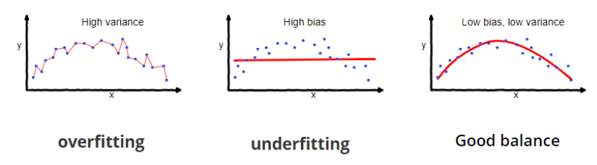

$References$

Halilaj, E., Rajagopal, A., Fiterau, M., Hicks, J. L., Hastie, T. J., & Delp, S. L. (2018). Machine learning in human movement biomechanics: Best practices, common pitfalls, and new opportunities. Journal of biomechanics, 81, 1–11. https://doi.org/10.1016/j.jbiomech.2018.09.009

Zago, M., Kleiner, A. F. R., & Federolf, P. A. (2020). Machine Learning Approaches to Human Movement Analysis. Frontiers in Bioengineering and Biotechnology, 8, 1573.

Alessandro, C., Delis, I., Nori, F., Panzeri, S., & Berret, B. (2013). Muscle synergies in neuroscience and robotics: from input-space to task-space perspectives. Frontiers in computational neuroscience, 7, 43.

Phinyomark, A., Petri, G., Ibáñez-Marcelo, E. et al. Analysis of Big Data in Gait Biomechanics: Current Trends and Future Directions. J. Med. Biol. Eng. 38, 244–260 (2018). https://doi.org/10.1007/s40846-017-0297-2

Rozumalski, A., & Schwartz, M. H. (2009). Crouch gait patterns defined using k-means cluster analysis are related to underlying clinical pathology. Gait & posture, 30(2), 155-160.